# Litterbag microcosm incubation: cumulative CO₂ flux, ¹³C partitioning, and decay kinetics

Adrianne

2026-09-17

# Scope and assumptions

This document takes the jar × sampling-week flux table from the litterbag microcosm incubation (rice, soy, wheat, no-plant control; ¹³C-labeled and unlabeled root litter; destructive harvests at T0, T10, T20, T30) and produces:

1. Cumulative respired C per jar by trapezoidal integration
2. Mean cumulative flux vs. time by crop
3. Cumulative flux normalized to (a) T0 root C added and (b) T0 total jar C
4. Plots of both normalizations
5. ¹³C two-pool partitioning → % of added root litter C respired over time
6. Single-exponential fits $C_t = C_0(1 - e^{-kt})$ per jar and per crop

**Assumptions baked into the code — change them if any are wrong:**

- `Flux_microg-CO2-C/g-soil/min` is µg CO₂-C per **gram dry soil** per minute, and `jar_dry_soil_g` is the matching soil mass. Fluxes are converted to a **whole-jar, per-day** basis before integration, because normalizing to root C (mg per jar) requires a per-jar numerator.
- `isotope == 13` (or anything ≥ 13) marks labeled jars; `12` marks unlabeled.
- **`sampling_wk` is a sampling label, not elapsed time.** The jars were sealed 2024-12-30 and the “week 1” headspace was taken 2024-12-31 — one day in, not seven. Integration therefore runs on **elapsed days computed from `sampling_date`**, with `(sampling_wk-1) × 7 + 1` used only as a fallback where a date is missing. The QC section prints the label-to-day mapping so you can see exactly what the column means for every other timepoint too.
- Flux between sampling dates is assumed to change linearly — that is what trapezoidal integration means. The sensitivity section quantifies the bias that introduces; it does not replace the method.
- The first headspace is at day 1, so cumulative flux is anchored at t = 0 by carrying that flux back over a single day (`anchor = "first"`). The alternative (`"zero"`) assumes zero flux at sealing, which is wrong for a rewetted soil; `"none"` discards the first interval. Over one day the choice is nearly immaterial — but it is the *entire* cumulative value for the T0 cohort.
- Crop labels in the file are `rice`, `soy`, `wheat`, `noPlant` (matched case-insensitively).

# Import and column renaming

The raw headers contain hyphens and slashes (`Flux_microg-CO2-C/g-soil/min`), which are not syntactic R names. `clean_names()` makes them predictable, then an explicit map shortens them. `any_of()` means a header that doesn’t match is skipped rather than throwing an error — the check immediately after tells you if that happened.

```r
data_path <- file.path(data_folder, "Jar-CO2-all-metadata.xlsx")   # <-- EDIT: path to your file

raw <- if (grepl("\\.csv$", data_path, ignore.case = TRUE)) {
  readr::read_csv(data_path, show_col_types = FALSE)
} else {
  readxl::read_excel(data_path)
}

raw <- janitor::clean_names(raw)   # e.g. "CO2_13C_at-pct" -> "co2_13c_at_pct"

rename_map <- c(
  jar           = "jar_num",
  wk            = "sampling_wk",
  samp_date     = "sampling_date",
  d13c_co2      = "co2_d13cvpdb_ppt",
  atpct_co2     = "co2_13c_at_pct",
  co2_ppm       = "co2_ppm_minus_blank",
  c_m           = "C_m",
  flux_ug_g_min = "flux_microg_co2_c_g_soil_min",
  sealed_min    = "time_sealed_min",
  gwc           = "jar_gwc",
  soil_g        = "jar_dry_soil_g",
  soil_c_g      = "jar_est_soil_c_g",
  root_mass_mg  = "t0_root_mass_mg",
  atpct_root    = "t0_root_13c_at_pct",
  root_c_pct    = "t0_root_c_pct",
  root_c_mg     = "t0_est_root_c_mg",
  jar_c_mg      = "t0_est_jar_c_mg"
)

dat <- raw %>% rename(any_of(rename_map))

# Did every expected column land? Anything printed here needs a manual fix above.
lost <- setdiff(names(rename_map), names(dat))
if (length(lost)) {
  message("NOT FOUND after rename: ", paste(lost, collapse = ", "))
  message("Actual columns: ", paste(names(raw), collapse = ", "))
}
```

```r
# Date the jars were sealed. Everything on the time axis is measured from here.
incubation_start <- as.Date("2024-12-30")

dat <- dat %>%
  mutate(
    # Tolerant crop matching; anything unmatched becomes NA and is caught in QC below
    crop  = factor(str_to_lower(str_trim(crop)),
                   levels = c("wheat", "rice", "soy", "noplant"),
                   labels = c("Wheat", "Rice", "Soy", "No plant")),
    label = factor(if_else(as.numeric(isotope) >= 13, "13C", "12C"),
                   levels = c("12C", "13C")),
    samp_date = as.Date(samp_date),
    # REAL elapsed time, not wk * 7: "week 1" was one day after sealing, so the nominal
    # week label and true elapsed time are not the same variable. wk * 7 is only a
    # fallback for rows with a missing or unparseable date.
    t_day = as.numeric(samp_date - incubation_start),
    t_day = if_else(is.na(t_day), (wk-1) * 7 + 1, t_day),
    # µg C g-soil^-1 min^-1  ->  mg C jar^-1 day^-1
    #   × soil_g : per-gram-soil -> per-jar
    #   × 1440   : per-minute    -> per-day
    #   ÷ 1000   : µg            -> mg
    flux_mg_jar_day = flux_ug_g_min * soil_g * 1440 / 1000
  )
```

# Quality control

Run this before anything else. Every downstream number depends on the sampling-week grid being what you think it is, and on root/jar C being constant within a jar.

```r
# Jar-level metadata; harvest cohort is inferred from the last week each jar was measured
jar_meta <- dat %>%
  group_by(jar) %>%
  summarise(
    crop = first(crop), label = first(label),
    n_obs = n(), first_wk = min(wk, na.rm = TRUE), last_wk = max(wk, na.rm = TRUE),
    root_c_mg = first(root_c_mg), jar_c_mg = first(jar_c_mg),
    root_c_varies = n_distinct(root_c_mg) > 1,   # should be FALSE everywhere
    .groups = "drop"
  ) %>%
  mutate(harvest = cut(last_wk, breaks = c(-Inf, 5, 15, 25, Inf),
                       labels = c("T0", "T10", "T20", "T30")))

list(
  n_rows              = nrow(dat),
  n_jars              = n_distinct(dat$jar),
  sampling_weeks      = sort(unique(dat$wk)),
  crop_NA             = sum(is.na(dat$crop)),
  duplicated_jar_wk   = sum(duplicated(dat[c("jar", "wk")])),
  flux_missing        = sum(is.na(dat$flux_mg_jar_day)),
  flux_negative       = sum(dat$flux_mg_jar_day < 0, na.rm = TRUE),
  root_c_inconsistent = sum(jar_meta$root_c_varies)
)
```

```
## $n_rows
## [1] 744
##
## $n_jars
## [1] 96
##
## $sampling_weeks
##  [1]  1  2  3  4  5  7  9 11 16 21 26 31
##
## $crop_NA
## [1] 0
##
## $duplicated_jar_wk
## [1] 0
##
## $flux_missing
## [1] 0
##
## $flux_negative
## [1] 0
##
## $root_c_inconsistent
## [1] 0
```

```r
# Design check: jars per harvest cohort × crop × isotope label
jar_meta %>% count(harvest, crop, label) %>%
  pivot_wider(names_from = label, values_from = n)
```

```
## # A tibble: 16 × 4
##    harvest crop     `13C` `12C`
##    <fct>   <fct>    <int> <int>
##  1 T0      Wheat        4    NA
##  2 T0      Rice         4     4
##  3 T0      Soy          4     4
##  4 T0      No plant    NA     4
##  5 T10     Wheat        4    NA
##  6 T10     Rice         4     4
##  7 T10     Soy          4     4
##  8 T10     No plant    NA     4
##  9 T20     Wheat        4    NA
## 10 T20     Rice         4     4
## 11 T20     Soy          4     4
## 12 T20     No plant    NA     4
## 13 T30     Wheat        4    NA
## 14 T30     Rice         4     4
## 15 T30     Soy          4     4
## 16 T30     No plant    NA     4
```

```r
# CHECK THIS TABLE. It shows what each sampling_wk label actually means in elapsed days.
# Week 1 should come out at day 1. If the later labels are not at 7-day multiples either,
# the integration is still correct (it runs on t_day), but any statement of the form
# "by week 20" needs to be phrased in elapsed days instead.
dat %>%
  group_by(wk) %>%
  summarise(n = n(), date_min = min(samp_date), date_max = max(samp_date),
            day_median = median(t_day), day_if_wk_x_7 = first(wk) * 7, .groups = "drop") %>%
  mutate(discrepancy_days = day_median - day_if_wk_x_7)
```

```
## # A tibble: 12 × 7
##       wk     n date_min   date_max   day_median day_if_wk_x_7 discrepancy_days
##    <dbl> <int> <date>     <date>          <dbl>         <dbl>            <dbl>
##  1     1    96 2024-12-31 2024-12-31          1             7               -6
##  2     2    72 2025-01-07 2025-01-07          8            14               -6
##  3     3    72 2025-01-14 2025-01-14         15            21               -6
##  4     4    72 2025-01-21 2025-01-21         22            28               -6
##  5     5    72 2025-01-28 2025-01-28         29            35               -6
##  6     7    72 2025-02-11 2025-02-11         43            49               -6
##  7     9    72 2025-02-25 2025-02-25         57            63               -6
##  8    11    72 2025-03-11 2025-03-11         71            77               -6
##  9    16    48 2025-04-16 2025-04-16        107           112               -5
## 10    21    48 2025-05-20 2025-05-20        141           147               -6
## 11    26    24 2025-06-24 2025-06-24        176           182               -6
## 12    31    24 2025-07-28 2025-07-28        210           217               -7
```

```r
# Independent sanity check on the flux column: rebuild it from headspace ppm and sealed
# time and see whether the two agree in rank. Getting this right requires headspace
# volume PER JAR, not one constant — soil mass varies jar to jar, and soil takes up space
# that air otherwise would. Volume by displacement (jar volume minus the volume the
# packed soil actually occupies) is the standard way to get this without measuring each
# jar by hand.
#
#   jar_volume_mL      : nominal capacity of the mason jar used
#   soil_volume_mL      = dry soil mass / bulk density of the PACKED soil (not particle
#                         density -- bulk density already accounts for pore space, which
#                         is what makes this a headspace-only calculation)
#   water_volume_mL     = water mass (from GWC) at ~1 g/mL, since that water also
#                         displaces air, not just the soil
#   headspace_volume_mL = jar_volume_mL - soil_volume_mL - water_volume_mL

jar_volume_mL  <- 473    # 16 oz (1 US pint) regular-mouth mason jar, nominal fill volume
                          # to the rim. Brands vary by a few mL (see note below); if you
                          # want the true sealed-headspace number rather than this label
                          # value, fill an empty jar with water to the sealing line and
                          # weigh it once -- five minutes, and it replaces this assumption
                          # entirely.
bulk_density   <- 1.45   # <-- EDIT if you have a measured value. 1.45 g/cm3 is a
                          #     mid-range literature figure for a sandy clay loam packed
                          #     to a typical (not compacted) bulk density -- sandy clay
                          #     loams commonly fall around 1.3-1.6 g/cm3 depending on how
                          #     firmly the soil was packed into the jar. This is soil
                          #     TEXTURE information, not a substitute for measuring bulk
                          #     density in your own jars: if you recorded jar volume
                          #     before and after adding soil, or weighed a known volume of
                          #     packed soil, use that number instead.
Temp <- 22                # <-- EDIT: incubation temperature, deg C
P    <- 1                 # atm

dat_hs <- dat %>%
  mutate(
    water_g       = soil_g * gwc,                      # assumes gwc is g water / g dry soil
    soil_vol_mL   = soil_g / bulk_density,
    water_vol_mL  = water_g / 1.0,
    headspace_mL  = jar_volume_mL - soil_vol_mL - water_vol_mL,
    headspace_L   = headspace_mL / 1000,
    umol_CO2       = co2_ppm * 1e-6 * P * headspace_L / (0.082057 * (Temp + 273.15)) * 1e6,
    check_ug_g_min = umol_CO2 * 12.011 / soil_g / sealed_min
  )

# Headspace should be a substantial, physically plausible fraction of jar volume -- if
# this comes out negative or under ~20%, jar_volume_mL or bulk_density is wrong.
dat_hs %>% summarise(headspace_mL_min = min(headspace_mL, na.rm = TRUE),
                      headspace_mL_max = max(headspace_mL, na.rm = TRUE),
                      pct_of_jar_min   = min(headspace_mL / jar_volume_mL, na.rm = TRUE) * 100,
                      pct_of_jar_max   = max(headspace_mL / jar_volume_mL, na.rm = TRUE) * 100)
```

```
## # A tibble: 1 × 4
##   headspace_mL_min headspace_mL_max pct_of_jar_min pct_of_jar_max
##              <dbl>            <dbl>          <dbl>          <dbl>
## 1             301.             329.           63.7           69.6
```

```r
dat_hs %>%
  filter(is.finite(check_ug_g_min), is.finite(flux_ug_g_min)) %>%
  summarise(
    pearson  = cor(check_ug_g_min, flux_ug_g_min),
    ratio_md = median(check_ug_g_min / flux_ug_g_min, na.rm = TRUE)
  )
```

```
## # A tibble: 1 × 2
##   pearson ratio_md
##     <dbl>    <dbl>
## 1   1.000    0.950
```

```r
# pearson ~ 1 means the flux column is the monotone function of ppm/time you expect --
# that check is INSENSITIVE to headspace volume (a wrong volume rescales every row the
# same way and correlation is scale-invariant), so it verifies the flux column's formula
# regardless of whether jar_volume_mL/bulk_density above are right.
# ratio_md is the scale factor between the two, and IS sensitive to headspace volume --
# treat it only as a rough check unless jar_volume_mL and bulk_density are confirmed.
# THAT SAID: jar_volume_mL and bulk_density can only be off by a small factor (a wrong
# jar size or an unrealistic bulk density is at most a 2-3x error). If ratio_md comes back
# far from 1 -- in the hundreds, thousands, or more -- headspace volume is not a candidate
# explanation, and the Flux column's own ppm-to-microg-C conversion is the place to look.
```

# Cumulative flux by trapezoidal integration

```r
#' Running cumulative integral by the trapezoid rule
#'
#' @param t      numeric time vector (days here); need not be sorted or evenly spaced
#' @param y      flux at each time, in units of mass per unit time
#' @param anchor how to treat the interval between t = 0 and the first measurement:
#'               "first" carries the first observed flux back to 0 (default),
#'               "zero"  assumes flux was 0 at t = 0,
#'               "none"  starts the integral at the first measurement
#' @return numeric vector, same length and order as `t`; NA where t or y is NA
cum_trap <- function(t, y, anchor = c("first", "zero", "none")) {
  anchor <- match.arg(anchor)
  stopifnot(length(t) == length(y))

  out <- rep(NA_real_, length(t))
  ok  <- !is.na(t) & !is.na(y)                 # integrate over complete pairs only
  if (sum(ok) == 0) return(out)

  ti <- t[ok]; yi <- y[ok]
  o  <- order(ti); ts <- ti[o]; ys <- yi[o]    # the trapezoid rule needs ascending time

  drop_anchor <- FALSE
  if (anchor != "none" && min(ts) > 0) {
    ts <- c(0, ts)
    ys <- c(if (anchor == "first") ys[1] else 0, ys)
    drop_anchor <- TRUE
  }

  dt   <- diff(ts)                                   # interval widths
  seg  <- dt * (head(ys, -1) + tail(ys, -1)) / 2     # area of each trapezoid
  cums <- c(0, cumsum(seg))                          # running total at each time point
  if (drop_anchor) cums <- cums[-1]                  # drop the synthetic t = 0 row

  res    <- numeric(length(cums))
  res[o] <- cums                                     # back to the original row order
  out[ok] <- res
  out
}
```

```r
flux <- dat %>%
  arrange(jar, wk) %>%
  group_by(jar) %>%
  mutate(
    cum_mg = cum_trap(t_day, flux_mg_jar_day, anchor = "first")   # mg CO2-C per jar
  ) %>%
  ungroup() %>%
  left_join(select(jar_meta, jar, harvest), by = "jar") %>%
  mutate(
    # (3a) total C respired as a percentage of the root C added
    #      na_if() stops no-plant jars (root_c_mg == 0) from becoming Inf
    cum_pct_root = 100 * cum_mg / na_if(root_c_mg, 0),
    # (3b) as a percentage of TOTAL jar C (soil C + root C) — defined for the no-plant
    #      controls too, so all four treatments sit on one axis
    cum_pct_jar  = 100 * cum_mg / na_if(jar_c_mg, 0)
  )

flux %>%
  select(jar, crop, label, wk, flux_mg_jar_day, cum_mg, cum_pct_root, cum_pct_jar) %>%
  head(12)
```

```
## # A tibble: 12 × 8
##      jar crop     label    wk flux_mg_jar_day cum_mg cum_pct_root cum_pct_jar
##    <dbl> <fct>    <fct> <dbl>           <dbl>  <dbl>        <dbl>       <dbl>
##  1     1 Rice     12C       1           0.378  0.378         1.99      0.0135
##  2     2 Rice     12C       1           0.696  0.696         3.38      0.0250
##  3     3 Rice     12C       1           0.722  0.722         3.96      0.0260
##  4     4 Rice     12C       1           1.13   1.13          6.14      0.0407
##  5     5 Soy      12C       1           0.562  0.562         4.03      0.0202
##  6     6 Soy      12C       1           0.584  0.584         4.42      0.0210
##  7     7 Soy      12C       1           0.740  0.740         5.41      0.0265
##  8     8 Soy      12C       1           0.445  0.445         3.27      0.0160
##  9    13 No plant 12C       1           0.676  0.676        NA         0.0244
## 10    14 No plant 12C       1           0.380  0.380        NA         0.0137
## 11    15 No plant 12C       1           0.668  0.668        NA         0.0242
## 12    16 No plant 12C       1           0.734  0.734        NA         0.0266
```

## Flux magnitude sanity check

```r
# ORDER-OF-MAGNITUDE CHECK ON THE FLUX COLUMN ITSELF. Root litter additions were 19-92 mg
# fresh mass, so at a generous 50% root C content, root C per jar tops out around 45 mg.
# Litter mineralization exceeding a few hundred percent of that is already the edge of
# plausible (see the mass-balance note in the 13C section); tens of thousands of percent
# is not, regardless of what root_c_mg says. If cum_mg (TOTAL jar CO2, before any 13C
# partitioning) is already in that range, the problem is upstream of root_c_mg entirely --
# it is in flux_mg_jar_day, which means it is in flux_ug_g_min, which is the Flux column
# as provided, not anything this pipeline derives. That would mean every cumulative-flux
# plot so far (sections 4-6, and the decay fits in section 9) inherits the same error, not
# just the 13C partitioning plot.
root_c_upper_bound_mg <- 92 * 0.5   # generous: max root mass x generous C fraction

flux %>%
  group_by(jar, crop) %>%
  summarise(final_cum_mg = max(cum_mg, na.rm = TRUE), .groups = "drop") %>%
  summarise(
    n_jars = n(),
    median_final_cum_mg = median(final_cum_mg),
    max_final_cum_mg     = max(final_cum_mg),
    fold_over_root_bound = max_final_cum_mg / root_c_upper_bound_mg
  )
```

```
## # A tibble: 1 × 4
##   n_jars median_final_cum_mg max_final_cum_mg fold_over_root_bound
##    <int>               <dbl>            <dbl>                <dbl>
## 1     96                17.8             50.4                 1.10
```

```r
dat %>%
  summarise(min = min(flux_ug_g_min, na.rm = TRUE),
            median = median(flux_ug_g_min, na.rm = TRUE),
            p99 = quantile(flux_ug_g_min, 0.99, na.rm = TRUE),
            max = max(flux_ug_g_min, na.rm = TRUE))
```

```
## # A tibble: 1 × 4
##         min   median     p99     max
##       <dbl>    <dbl>   <dbl>   <dbl>
## 1 0.0000244 0.000658 0.00308 0.00393
```

## Summary by crop

```r
#' Mean ± SE across jars at each crop × week, carrying n so dropout stays visible
summarise_by_crop <- function(df, yvar, by_label = FALSE) {
  grps <- c("crop", "wk", if (by_label) "label")
  df %>%
    group_by(across(all_of(grps))) %>%
    summarise(
      # Jars are grouped by the shared sampling label, but positioned on the x axis at
      # their true elapsed time — the two differ most at the first timepoint (day 1).
      t_wk = mean(t_day, na.rm = TRUE) / 7,
      mean = mean(.data[[yvar]], na.rm = TRUE),
      sd   = sd(.data[[yvar]],  na.rm = TRUE),
      n    = sum(!is.na(.data[[yvar]])),
      se   = sd / sqrt(n),
      .groups = "drop"
    )
}
```

# Mean cumulative flux vs. time, by crop

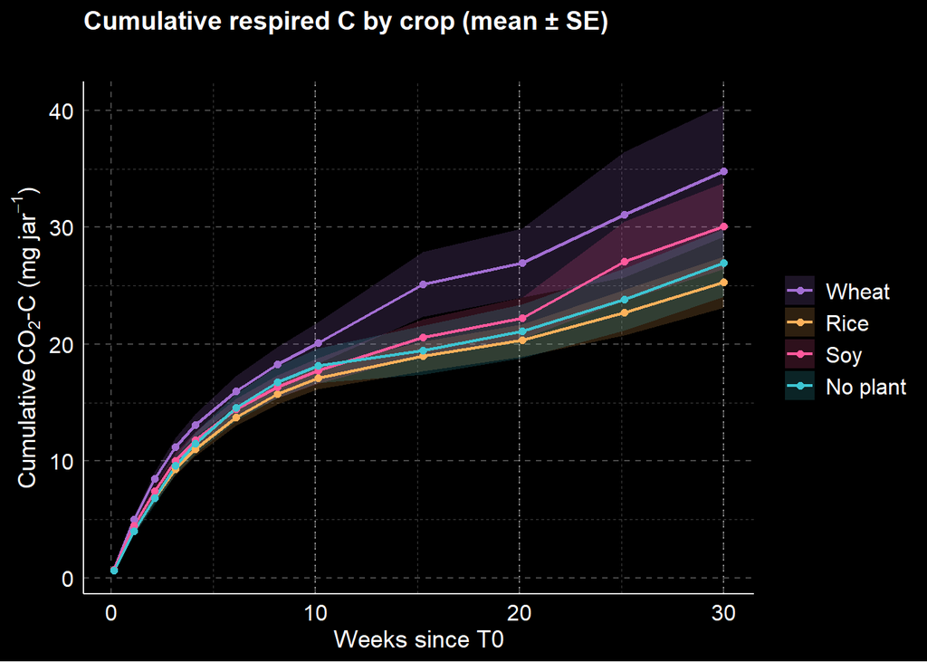

```r
cum_summary <- summarise_by_crop(flux, "cum_mg")

ggplot(cum_summary, aes(t_wk, mean, colour = crop, fill = crop)) +
  geom_vline(xintercept = c(10, 20, 30), linetype = "dotted", colour = "grey60") +
  geom_ribbon(aes(ymin = mean - se, ymax = mean + se), alpha = 0.18, colour = NA) +
  geom_line(linewidth = 0.8) +
  geom_point(size = 1.6) +
  scale_colour_manual(values = crop_colors) +
  scale_fill_manual(values = crop_colors) +
  labs(x = "Weeks since T0", y = expression("Cumulative "*CO[2]*"-C (mg jar"^-1*")"),
       colour = NULL, fill = NULL,
       title = "Cumulative respired C by crop (mean ± SE)",
       subtitle = "Dotted lines mark destructive harvests; replicate number drops at each one")
```

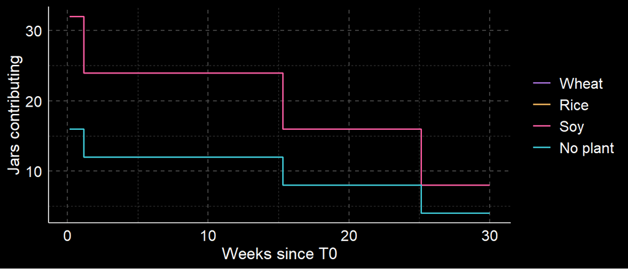

```r
# How many jars sit behind each point above. Read the two plots together.
ggplot(cum_summary, aes(t_wk, n, colour = crop)) +
  geom_step(linewidth = 0.7) +
  scale_colour_manual(values = crop_colors) +
  labs(x = "Weeks since T0", y = "Jars contributing", colour = NULL)
```

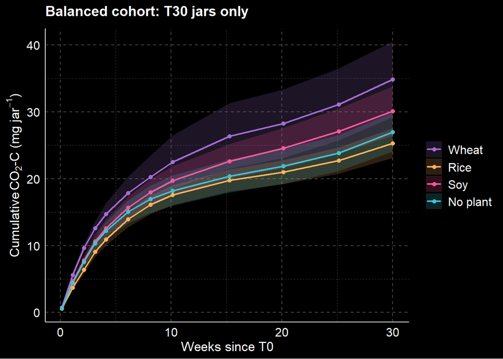

```r
flux_bal <- filter(flux, harvest == "T30")

summarise_by_crop(flux_bal, "cum_mg") %>%
  ggplot(aes(t_wk, mean, colour = crop, fill = crop)) +
  geom_ribbon(aes(ymin = mean - se, ymax = mean + se), alpha = 0.18, colour = NA) +
  geom_line(linewidth = 0.8) + geom_point(size = 1.6) +
  scale_colour_manual(values = crop_colors) + scale_fill_manual(values = crop_colors) +
  labs(x = "Weeks since T0", y = expression("Cumulative "*CO[2]*"-C (mg jar"^-1*")"),
       colour = NULL, fill = NULL, title = "Balanced cohort: T30 jars only")
```

# Normalized cumulative flux

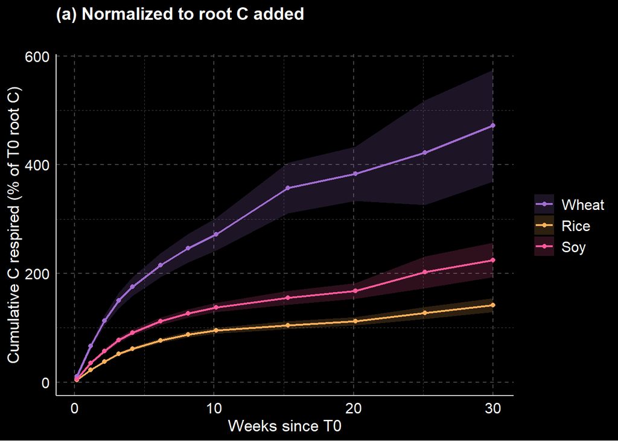

```r
p_root <- summarise_by_crop(filter(flux, crop != "No plant"), "cum_pct_root") %>%
  ggplot(aes(t_wk, mean, colour = crop, fill = crop)) +
  geom_ribbon(aes(ymin = mean - se, ymax = mean + se), alpha = 0.18, colour = NA) +
  geom_line(linewidth = 0.8) + geom_point(size = 1.5) +
  scale_colour_manual(values = crop_colors) + scale_fill_manual(values = crop_colors) +
  labs(x = "Weeks since T0", y = "Cumulative C respired (% of T0 root C)",
       colour = NULL, fill = NULL,
       title = "(a) Normalized to root C added",
       subtitle = "Total CO2, not litter-derived CO2 — values can exceed 100%")

p_jar <- summarise_by_crop(flux, "cum_pct_jar") %>%
  ggplot(aes(t_wk, mean, colour = crop, fill = crop)) +
  geom_ribbon(aes(ymin = mean - se, ymax = mean + se), alpha = 0.18, colour = NA) +
  geom_line(linewidth = 0.8) + geom_point(size = 1.5) +
  scale_colour_manual(values = crop_colors) + scale_fill_manual(values = crop_colors) +
  labs(x = "Weeks since T0", y = "Cumulative C respired (% of T0 total jar C)",
       colour = NULL, fill = NULL,
       title = "(b) Normalized to total jar C",
       subtitle = "Includes no-plant controls")

p_root
```

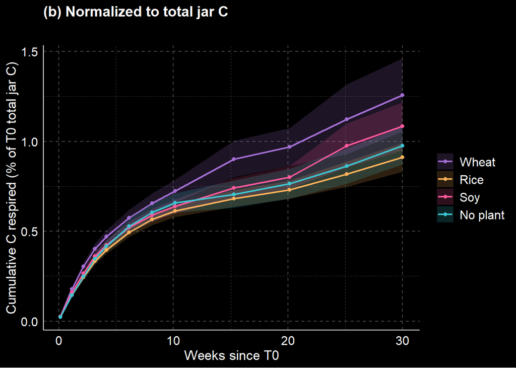

```r
p_jar
```

Normalization (a) divides **total** jar CO₂ by root C, so it includes soil-derived CO₂ and will exceed 100% given enough time. It answers “how much C left the jar per unit litter added”, not “how much of the litter decomposed” — the ¹³C partitioning section answers the second question. Normalization (b) is the one to use for cross-treatment comparison, since it is defined for the no-plant controls.

## Control-corrected flux (suggested addition)

The unlabeled jars have no isotopic handle, but the no-plant controls — same soil, empty litterbag — give a non-isotopic estimate of litter-induced CO₂: subtract the mean control cumulative flux, expressed per gram soil C, from each planted jar. Because the control bag is present but empty, the bag material itself is already differenced out. The difference is litter-derived C **plus any priming**, which is exactly why it will not agree with the ¹³C estimate — and the size of the disagreement is itself the priming signal.

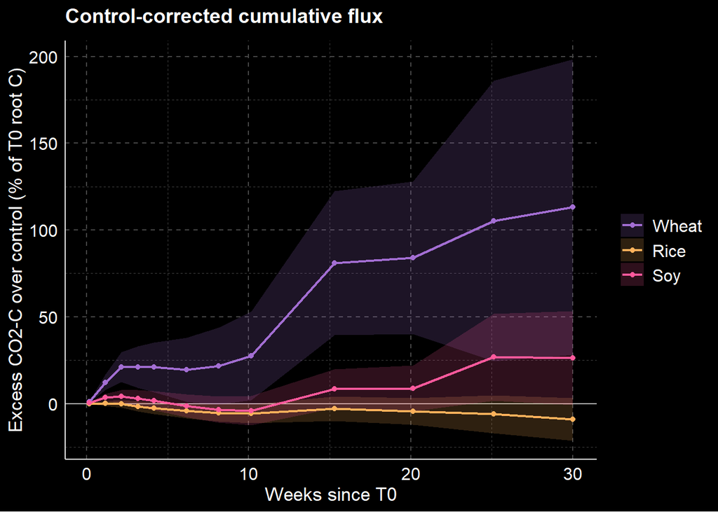

```r
ctrl <- flux %>%
  filter(crop == "No plant") %>%
  mutate(cum_per_gC = cum_mg / soil_c_g) %>%
  group_by(wk) %>%
  summarise(ctrl_cum_per_gC = mean(cum_per_gC, na.rm = TRUE), .groups = "drop")

flux_cc <- flux %>%
  filter(crop != "No plant") %>%
  left_join(ctrl, by = "wk") %>%
  mutate(
    cum_excess_mg   = cum_mg - ctrl_cum_per_gC * soil_c_g,   # mg C above the control
    excess_pct_root = 100 * cum_excess_mg / na_if(root_c_mg, 0)
  )

summarise_by_crop(flux_cc, "excess_pct_root") %>%
  ggplot(aes(t_wk, mean, colour = crop, fill = crop)) +
  geom_hline(yintercept = 0, colour = "grey70") +
  geom_ribbon(aes(ymin = mean - se, ymax = mean + se), alpha = 0.18, colour = NA) +
  geom_line(linewidth = 0.8) + geom_point(size = 1.5) +
  scale_colour_manual(values = crop_colors) + scale_fill_manual(values = crop_colors) +
  labs(x = "Weeks since T0", y = "Excess CO2-C over control (% of T0 root C)",
       colour = NULL, fill = NULL, title = "Control-corrected cumulative flux")
```

# ¹³C partitioning: percent of labeled litter respired

Two-source mixing on each headspace sample:

$$f_{root} = \frac{at\%_{sample} -
at\%_{background}}{at\%_{root} - at\%_{background}}$$

`at%_background` is the ¹³C content of CO₂ in jars that received *unlabeled* litter of the same crop at the same week — that mixture of soil- and root-derived CO₂ is the correct null. The no-plant jars (empty litterbag, unlabeled only) are not used here: they contain no root C at all, so they estimate the soil-only endmember rather than the soil-plus-unlabeled- root mixture that a labeled jar would have in the absence of enrichment. They are used in the control-corrected subsection instead, where a soil-only reference is what you want.

Partitioning is applied to the **instantaneous flux**, and the litter-derived flux is then integrated. Partitioning the cumulative curve instead would be wrong, because the source mixture changes over time.

```r
background <- dat %>%
  filter(label == "12C", crop != "No plant") %>%
  group_by(crop, wk) %>%
  summarise(atpct_bg = mean(atpct_co2, na.rm = TRUE), .groups = "drop")

bg_global <- mean(background$atpct_bg, na.rm = TRUE)   # fallback for unmatched weeks

labeled <- flux %>%
  filter(label == "13C", crop != "No plant") %>%
  left_join(background, by = c("crop", "wk")) %>%
  mutate(
    atpct_bg   = coalesce(atpct_bg, bg_global),
    f_root_raw = (atpct_co2 - atpct_bg) / (atpct_root - atpct_bg),
    f_root     = pmin(pmax(f_root_raw, 0), 1),          # constrain to [0,1] for integration
    flux_root_mg_jar_day = f_root * flux_mg_jar_day
  ) %>%
  arrange(jar, wk) %>%
  group_by(jar) %>%
  mutate(cum_root_mg = cum_trap(t_day, flux_root_mg_jar_day, anchor = "first")) %>%
  ungroup() %>%
  mutate(pct_root_respired = 100 * cum_root_mg / na_if(root_c_mg, 0))

# How often does the raw mixing fraction fall outside [0,1]? Frequent excursions mean the
# enrichment is too close to background relative to analytical precision.
labeled %>%
  summarise(
    n        = sum(is.finite(f_root_raw)),
    below_0  = sum(f_root_raw < 0, na.rm = TRUE),
    above_1  = sum(f_root_raw > 1, na.rm = TRUE),
    median_f = median(f_root_raw, na.rm = TRUE),
    min_enrichment_atpct = min(atpct_root - atpct_bg, na.rm = TRUE)
  )
```

```
## # A tibble: 1 × 5
##       n below_0 above_1 median_f min_enrichment_atpct
##   <int>   <int>   <int>    <dbl>                <dbl>
## 1   372       0       0   0.0498                0.443
```

```r
# A percentage in the thousands or millions is not explained by priming or a biased
# composite root C% (those cost you tens to low hundreds of percent at most) -- it means
# root_c_mg is vanishingly small for at least some jars, almost certainly a units or
# data-entry problem rather than biology. This chunk finds exactly which jar(s).

# 1. Does root_c_mg itself contain implausibly small values? Compare against the overall
#    distribution -- a true outlier will sit orders of magnitude below the rest, not just
#    somewhat lower.
labeled %>%
  distinct(jar, crop, root_c_mg) %>%
  summarise(min = min(root_c_mg), p01 = quantile(root_c_mg, 0.01),
            median = median(root_c_mg), max = max(root_c_mg))
```

```
## # A tibble: 1 × 4
##     min   p01 median   max
##   <dbl> <dbl>  <dbl> <dbl>
## 1  5.04  5.05   11.7  19.4
```

```r
# 2. The jar-week rows actually driving the extreme percentages, worst first. Cross-check
#    root_c_mg for these specific jars against your raw spreadsheet: look for a value
#    entered in the wrong unit (g instead of mg), a shifted decimal point, or a row that
#    picked up 0 or a blank that something upstream silently coerced to a tiny number.
labeled %>%
  select(jar, crop, wk, harvest, root_c_mg, cum_root_mg, f_root, pct_root_respired) %>%
  arrange(desc(pct_root_respired)) %>%
  head(15)
```

```
## # A tibble: 15 × 8
##      jar crop     wk harvest root_c_mg cum_root_mg f_root pct_root_respired
##    <dbl> <fct> <dbl> <fct>       <dbl>       <dbl>  <dbl>             <dbl>
##  1    47 Rice     11 T10          17.2        6.12 0.184               35.6
##  2    47 Rice      9 T10          17.2        5.70 0.212               33.2
##  3    47 Rice      7 T10          17.2        5.02 0.251               29.2
##  4    48 Rice     11 T10          18.6        5.22 0.200               28.1
##  5   101 Rice     31 T30          17.5        4.83 0.121               27.6
##  6    48 Rice      9 T10          18.6        5.02 0.163               27.0
##  7   101 Rice     26 T30          17.5        4.47 0.129               25.6
##  8   101 Rice     21 T30          17.5        4.27 0.0479              24.4
##  9   101 Rice     16 T30          17.5        4.19 0.118               23.9
## 10    48 Rice      7 T10          18.6        4.42 0.457               23.8
## 11   101 Rice     11 T30          17.5        4.05 0.0597              23.2
## 12    47 Rice      5 T10          17.2        3.85 0.346               22.4
## 13   101 Rice      9 T30          17.5        3.78 0.253               21.6
## 14   102 Rice     31 T30          17.1        3.67 0.102               21.5
## 15    45 Rice     11 T10          18.0        3.66 0.140               20.4
```

```r
# 3. Is the mean being pulled around by a small number of jars? Compare mean vs. median at
#    each week -- if they disagree by orders of magnitude, the mean is not representative
#    and should not be trusted until the jar(s) above are fixed or excluded.
labeled %>%
  group_by(crop, wk) %>%
  summarise(n = n(), mean_pct = mean(pct_root_respired, na.rm = TRUE),
            median_pct = median(pct_root_respired, na.rm = TRUE),
            max_pct = max(pct_root_respired, na.rm = TRUE), .groups = "drop") %>%
  filter(mean_pct > 2 * median_pct)   # rows where the mean is clearly outlier-driven
```

```
## # A tibble: 0 × 6
## # ℹ 6 variables: crop <fct>, wk <dbl>, n <int>, mean_pct <dbl>,
## #   median_pct <dbl>, max_pct <dbl>
```

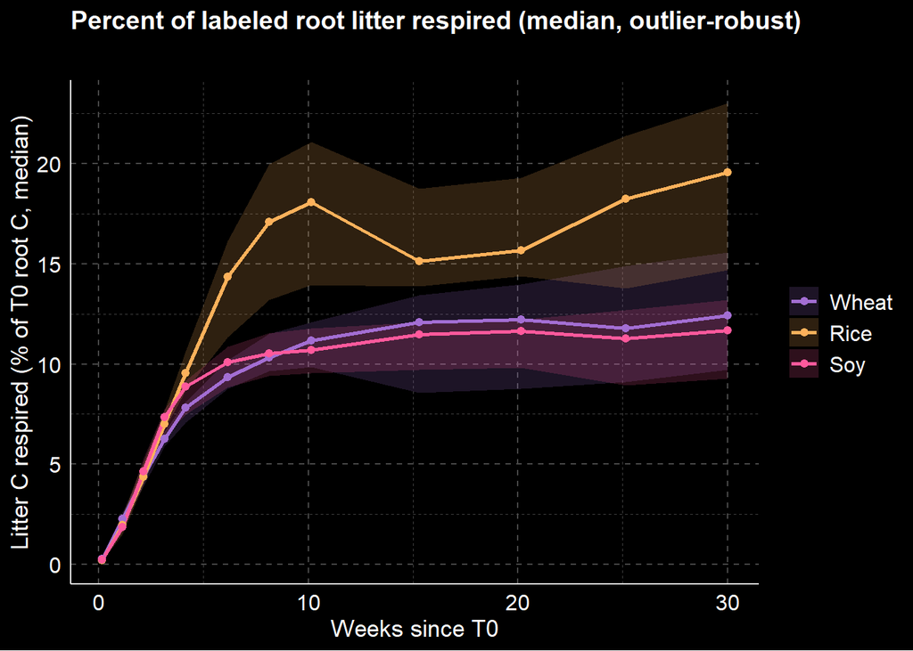

```r
# STOPGAP, not a fix: median + IQR instead of mean + SE, so the plot is legible while
# the jar(s) above are traced back to the raw sheet and corrected. Once root_c_mg is
# fixed, re-run plot-partition (mean-based) as the version to report.
labeled %>%
  group_by(crop, wk) %>%
  summarise(t_wk = mean(t_day, na.rm = TRUE) / 7,
            median = median(pct_root_respired, na.rm = TRUE),
            q25 = quantile(pct_root_respired, 0.25, na.rm = TRUE),
            q75 = quantile(pct_root_respired, 0.75, na.rm = TRUE), .groups = "drop") %>%
  ggplot(aes(t_wk, median, colour = crop, fill = crop)) +
  geom_ribbon(aes(ymin = q25, ymax = q75), alpha = 0.18, colour = NA) +
  geom_line(linewidth = 0.9) + geom_point(size = 1.8) +
  scale_colour_manual(values = crop_colors) + scale_fill_manual(values = crop_colors) +
  labs(x = "Weeks since T0", y = "Litter C respired (% of T0 root C, median)",
       colour = NULL, fill = NULL,
       title = "Percent of labeled root litter respired (median, outlier-robust)",
       subtitle = "Diagnostic view only -- use the mean-based plot once root_c_mg is corrected")
```

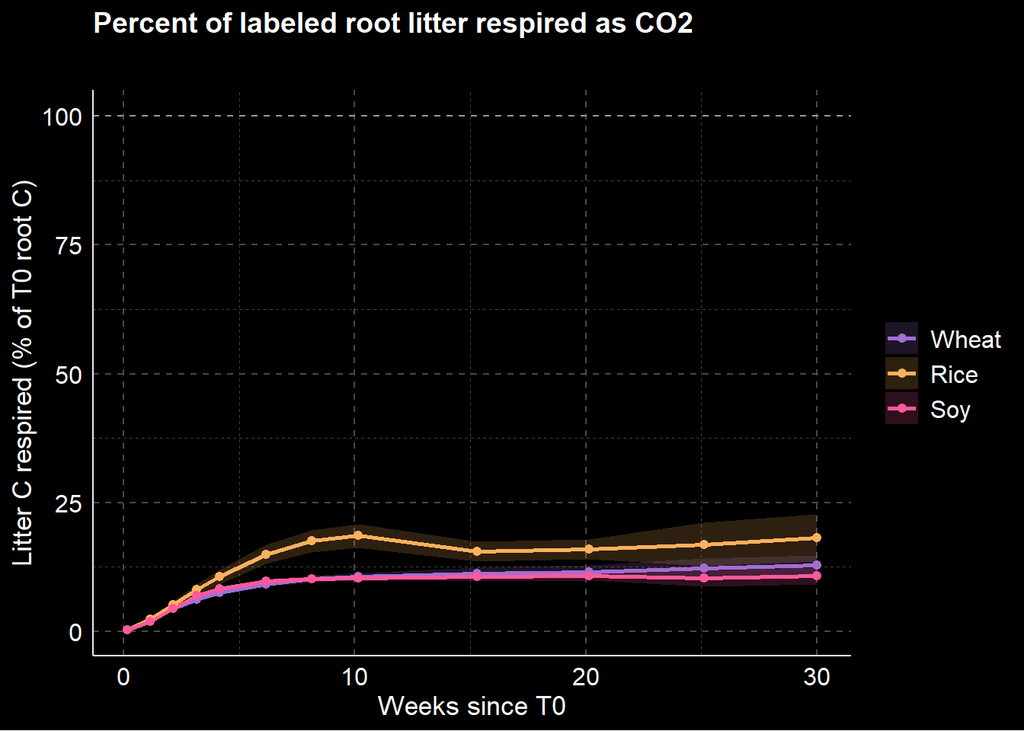

```r
summarise_by_crop(labeled, "pct_root_respired") %>%
  ggplot(aes(t_wk, mean, color = crop, fill = crop)) +
  geom_hline(yintercept = 100, linetype = "dashed", color = "grey60") +
  geom_ribbon(aes(ymin = mean - se, ymax = mean + se), alpha = 0.18, color = NA) +
  geom_line(linewidth = 0.9) + geom_point(size = 1.8) +
  scale_color_manual(values = crop_colors) + scale_fill_manual(values = crop_colors) +
  labs(x = "Weeks since T0", y = "Litter C respired (% of T0 root C)",
       color = NULL, fill = NULL,
       title = "Percent of labeled root litter respired as CO2",
       subtitle = "13C jars only; dashed line = complete mineralization of the added litter")
```

```r
# Mass-balance diagnostic. Cumulative litter-derived C above 100% of the T0 root C pool is
# not automatically a coding error — it is what happens when the mixing model attributes
# primed SOM to the litter, when at%_root drifts as the enriched labile fraction is
# consumed, or when T0_est-root-C_mg is underestimated. Note that root C% is a CROP
# COMPOSITE, so an error in it shifts an entire crop's denominator by a constant factor:
# an exceedance confined to one crop points at the composite before it points at biology.
labeled %>%
  group_by(crop, jar) %>%
  summarise(max_pct = max(pct_root_respired, na.rm = TRUE), .groups = "drop") %>%
  group_by(crop) %>%
  summarise(n_jars = n(), median_max = median(max_pct),
            n_over_100 = sum(max_pct > 100), max_observed = max(max_pct))
```

```
## # A tibble: 3 × 5
##   crop  n_jars median_max n_over_100 max_observed
##   <fct>  <int>      <dbl>      <int>        <dbl>
## 1 Wheat     16       10.6          0         17.3
## 2 Rice      16       16.6          0         35.6
## 3 Soy       16       10.2          0         13.5
```

# Decay kinetics: $C_t = C_0(1 - e^{-kt})$

`SSasympOrig` is the self-starting form of exactly this model in R: `SSasympOrig(t, Asym, lrc)` = `Asym * (1 - exp(-exp(lrc) * t))`, so $C_0$ = `Asym` and $k$ = `exp(lrc)`. Self-starting removes the need for hand-picked starting values, which is what usually breaks `nls()` on short series.

```r
#' Fit C_t = C_0 (1 - exp(-k t)); returns NULL instead of erroring on non-convergence
fit_asym <- function(df, yvar = "cum_mg", min_points = 4) {
  d <- data.frame(t = df$t_day, y = df[[yvar]])
  d <- d[complete.cases(d) & is.finite(d$y), ]
  if (length(unique(d$t)) < min_points || max(d$y) <= 0) return(NULL)
  tryCatch(nls(y ~ SSasympOrig(t, Asym, lrc), data = d), error = function(e) NULL)
}

#' Pull C_0 and k (per day and per week) out of a fitted model
pars_of <- function(fit) {
  if (is.null(fit)) {
    return(tibble(C0 = NA_real_, k_day = NA_real_, k_wk = NA_real_,
                  halflife_wk = NA_real_, rse = NA_real_))
  }
  co <- coef(fit)
  k  <- unname(exp(co[["lrc"]]))                      # lrc is log(k), k in day^-1
  tibble(C0 = unname(co[["Asym"]]), k_day = k, k_wk = k * 7,
         halflife_wk = log(2) / (k * 7),
         rse = summary(fit)$sigma)
}
```

## Per-jar fits

Jars from the T0 and T10 cohorts have too few points, or too short a span, to identify an asymptote. `min_points = 4` drops the worst cases, but a converged fit on an 11-week series still has a nearly unidentifiable $C_0$ — the model is extrapolating to a plateau the data never reach. Trust $k$ more than $C_0$ for the short cohorts, and report both *by cohort* so that pattern stays visible.

```r
jar_fits <- flux %>%
  filter(crop != "No plant") %>%
  group_by(jar, crop, label, harvest) %>%
  nest() %>%
  mutate(
    fit_mg  = map(data, fit_asym, yvar = "cum_mg"),
    pars_mg = map(fit_mg, pars_of)
  ) %>%
  select(-data, -fit_mg) %>%
  unnest(pars_mg) %>%
  ungroup()

jar_fits %>%
  filter(!is.na(k_wk)) %>%
  group_by(crop, harvest) %>%
  summarise(n = n(),
            C0_mg_median = median(C0), C0_mg_sd = sd(C0),
            k_wk_median  = median(k_wk), k_wk_sd = sd(k_wk),
            halflife_wk  = median(halflife_wk), .groups = "drop")
```

```
## # A tibble: 9 × 8
##   crop  harvest     n C0_mg_median C0_mg_sd k_wk_median k_wk_sd halflife_wk
##   <fct> <fct>   <int>        <dbl>    <dbl>       <dbl>   <dbl>       <dbl>
## 1 Wheat T10         4         16.6     4.94       0.222  0.0535        3.16
## 2 Wheat T20         4         28.4     7.30       0.163  0.0353        4.25
## 3 Wheat T30         4         29.6    12.6        0.137  0.0337        5.15
## 4 Rice  T10         8         19.1     6.73       0.191  0.0439        3.63
## 5 Rice  T20         8         20.1     6.42       0.200  0.0333        3.47
## 6 Rice  T30         8         23.6     5.89       0.143  0.0169        4.85
## 7 Soy   T10         8         18.2     6.59       0.235  0.0693        2.95
## 8 Soy   T20         8         19.3     4.52       0.207  0.0287        3.36
## 9 Soy   T30         8         28.5    10.6        0.139  0.0294        5.01
```

```r
# The same fits on the 13C-partitioned litter curve, where C_0 is directly interpretable
# as the labile *fraction* of the added litter (%) rather than an absolute mass.
lab_fits <- labeled %>%
  group_by(jar, crop, harvest) %>%
  nest() %>%
  mutate(pars = map(data, ~ pars_of(fit_asym(.x, yvar = "pct_root_respired")))) %>%
  select(-data) %>% unnest(pars) %>% ungroup()

lab_fits %>%
  filter(!is.na(k_wk)) %>%
  group_by(crop) %>%
  summarise(n = n(),
            labile_pct_median = median(C0), labile_pct_sd = sd(C0),
            k_wk_median = median(k_wk), k_wk_sd = sd(k_wk), .groups = "drop")
```

```
## # A tibble: 3 × 6
##   crop      n labile_pct_median labile_pct_sd k_wk_median k_wk_sd
##   <fct> <int>             <dbl>         <dbl>       <dbl>   <dbl>
## 1 Wheat    12              13.0          3.11       0.212  0.0637
## 2 Rice     12              21.4         19.0        0.151  0.0597
## 3 Soy      12              11.4          2.01       0.275  0.0331
```

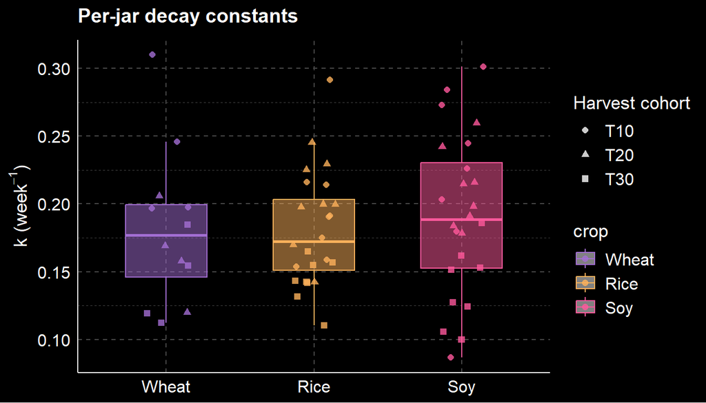

```r
jar_fits %>%
  filter(!is.na(k_wk), k_wk < 5) %>%   # drop numerically absurd fits before plotting
  ggplot(aes(crop, k_wk, colour = crop, fill = crop)) +
  geom_boxplot(outlier.shape = NA, width = 0.55, alpha = 0.5) +
  geom_jitter(aes(shape = harvest), width = 0.15, size = 1.8, alpha = 0.8) +
  scale_colour_manual(values = crop_colors) +
  scale_fill_manual(values = crop_colors, guide = "none") +
  guides(shape = guide_legend(override.aes = list(colour = annotation_text_color,
                                                  fill = annotation_text_color))) +
  labs(x = NULL, y = expression("k (week"^-1*")"), shape = "Harvest cohort",
       title = "Per-jar decay constants")
```

## Pooled fits by crop, with curves over the data

```r
crop_fits <- flux %>%
  filter(crop != "No plant") %>%
  group_by(crop, label) %>%
  nest() %>%
  mutate(fit  = map(data, fit_asym, yvar = "cum_mg"),
         pars = map(fit, pars_of))

crop_fits %>% select(crop, label, pars) %>% unnest(pars)
```

```
## # A tibble: 5 × 7
## # Groups:   crop, label [5]
##   crop  label    C0  k_day  k_wk halflife_wk   rse
##   <fct> <fct> <dbl>  <dbl> <dbl>       <dbl> <dbl>
## 1 Rice  12C    20.8 0.0250 0.175        3.96  3.95
## 2 Soy   12C    33.6 0.0146 0.102        6.78  4.90
## 3 Rice  13C    23.8 0.0200 0.140        4.94  3.14
## 4 Soy   13C    19.4 0.0252 0.176        3.93  2.79
## 5 Wheat 13C    31.6 0.0165 0.115        6.02  5.03
```

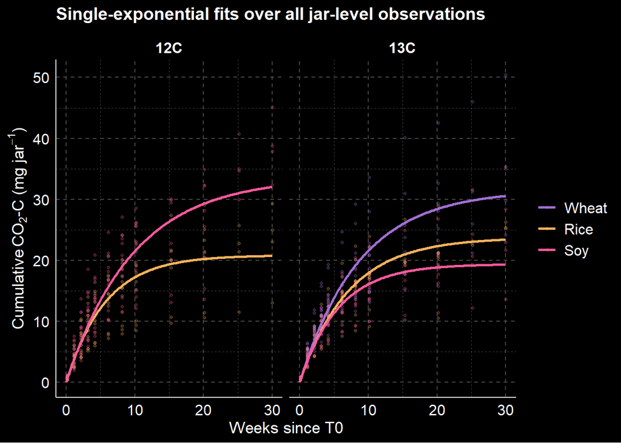

```r
pred <- crop_fits %>%
  filter(!map_lgl(fit, is.null)) %>%
  mutate(grid = map2(fit, data, ~ tibble(
    t_day = seq(0, max(.y$t_day, na.rm = TRUE), length.out = 200)
  ) %>% mutate(cum_mg = predict(.x, newdata = data.frame(t = t_day))))) %>%
  select(crop, label, grid) %>% unnest(grid) %>% mutate(wk = t_day / 7)

ggplot() +
  geom_point(data = filter(flux, crop != "No plant"),
             aes(t_day / 7, cum_mg, colour = crop), alpha = 0.25, size = 0.9) +
  geom_line(data = pred, aes(wk, cum_mg, colour = crop), linewidth = 1) +
  facet_wrap(~ label) +
  scale_colour_manual(values = crop_colors) +
  labs(x = "Weeks since T0", y = expression("Cumulative "*CO[2]*"-C (mg jar"^-1*")"),
       colour = NULL, title = "Single-exponential fits over all jar-level observations")
```

## Optional: two-pool model and model comparison

A single exponential forces one labile pool with one rate. If residuals are structured (early points under-predicted, late points over-predicted), a two-pool model usually fits better; AIC tells you whether the extra two parameters earn their keep.

```r
fit_two_pool <- function(df, yvar = "cum_mg") {
  d <- data.frame(t = df$t_day, y = df[[yvar]])
  d <- d[complete.cases(d) & is.finite(d$y), ]
  one <- fit_asym(df, yvar)
  if (is.null(one) || length(unique(d$t)) < 6) return(NULL)
  st <- coef(one); A <- st[["Asym"]]; k <- exp(st[["lrc"]])
  tryCatch(
    nls(y ~ C1 * (1 - exp(-k1 * t)) + C2 * (1 - exp(-k2 * t)), data = d,
        start   = list(C1 = 0.4 * A, k1 = 4 * k, C2 = 0.6 * A, k2 = 0.25 * k),
        algorithm = "port",
        lower   = c(C1 = 0, k1 = 1e-6, C2 = 0, k2 = 1e-8),
        control = nls.control(maxiter = 200)),
    error = function(e) NULL)
}

crop_fits %>%
  mutate(fit2 = map(data, fit_two_pool)) %>%
  filter(!map_lgl(fit, is.null), !map_lgl(fit2, is.null)) %>%
  transmute(crop, label,
            AIC_one = map_dbl(fit,  AIC),
            AIC_two = map_dbl(fit2, AIC),
            delta   = AIC_one - AIC_two) %>%   # delta > 2 favours the two-pool model
  ungroup()
```

```
## # A tibble: 1 × 5
##   crop  label AIC_one AIC_two delta
##   <fct> <fct>   <dbl>   <dbl> <dbl>
## 1 Soy   13C      610.    607.  2.68
```

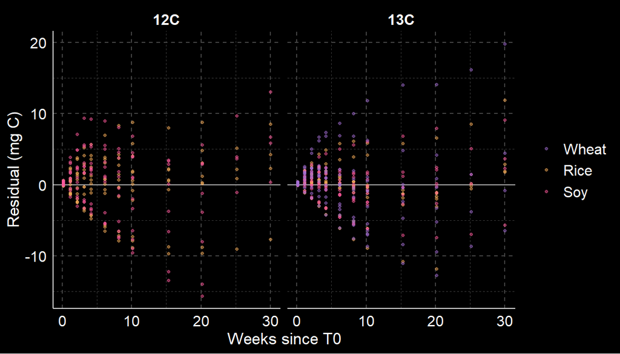

```r
# Residuals vs. time for the one-pool fits. Cumulative data are autocorrelated by
# construction, so these residuals will always show runs — what you are looking for is
# systematic curvature, which indicates the wrong functional form.
crop_fits %>%
  filter(!map_lgl(fit, is.null)) %>%
  mutate(res = map2(fit, data, ~ tibble(
    t_day = .y$t_day[complete.cases(.y$cum_mg) & is.finite(.y$cum_mg)],
    r     = residuals(.x)))) %>%
  select(crop, label, res) %>% unnest(res) %>%
  ggplot(aes(t_day / 7, r, colour = crop)) +
  geom_hline(yintercept = 0, colour = "grey70") +
  geom_point(alpha = 0.5, size = 0.9) +
  facet_wrap(~ label) +
  scale_colour_manual(values = crop_colors) +
  labs(x = "Weeks since T0", y = "Residual (mg C)", colour = NULL)
```

# Sensitivity: how much does the interpolation rule matter?

Trapezoidal integration stays the reported method. This section exists only to put a number on its bias, so the choice is documented rather than assumed harmless. Log-linear interpolation is the natural comparison: across an interval where flux decays exponentially, it is exact where the trapezoid is an overestimate.

```r
#' Cumulative integral with log-linear (exponential) interpolation between points
#' Exact analytic form on each interval: integral of y1*exp(-lambda*t) = (y2-y1)*dt/log(y2/y1)
#' Falls back to the trapezoid on any interval with a non-positive or flat endpoint.
cum_loglin <- function(t, y, anchor = "first") {
  out <- rep(NA_real_, length(t))
  ok  <- !is.na(t) & !is.na(y)
  if (!any(ok)) return(out)
  ti <- t[ok]; yi <- y[ok]; o <- order(ti); ts <- ti[o]; ys <- yi[o]

  drop_anchor <- FALSE
  if (anchor != "none" && min(ts) > 0) {
    ts <- c(0, ts); ys <- c(ys[1], ys); drop_anchor <- TRUE
  }

  y1 <- head(ys, -1); y2 <- tail(ys, -1); dt <- diff(ts)
  ratio <- ifelse(y1 > 0 & y2 > 0, y2 / y1, NA_real_)   # NA avoids log() of <= 0
  seg   <- ifelse(!is.na(ratio) & ratio != 1,
                  (y2 - y1) * dt / log(ratio),           # log-linear
                  dt * (y1 + y2) / 2)                    # trapezoid fallback
  cums <- c(0, cumsum(seg))
  if (drop_anchor) cums <- cums[-1]
  res <- numeric(length(cums)); res[o] <- cums; out[ok] <- res
  out
}

sens <- flux %>%
  arrange(jar, wk) %>%
  group_by(jar) %>%
  mutate(cum_mg_loglin = cum_loglin(t_day, flux_mg_jar_day)) %>%
  slice_max(t_day, n = 1, with_ties = FALSE) %>%   # final cumulative value per jar
  ungroup()

sens %>%
  group_by(crop) %>%
  summarise(
    n            = n(),
    trap_mg      = median(cum_mg),
    loglin_mg    = median(cum_mg_loglin),
    pct_diff_med = median(100 * (cum_mg - cum_mg_loglin) / cum_mg_loglin),
    pct_diff_max = max(100 * (cum_mg - cum_mg_loglin) / cum_mg_loglin),
    .groups = "drop"
  )
```

```
## # A tibble: 4 × 6
##   crop         n trap_mg loglin_mg pct_diff_med pct_diff_max
##   <fct>    <int>   <dbl>     <dbl>        <dbl>        <dbl>
## 1 Wheat       16    19.5      19.2         1.53         3.22
## 2 Rice        32    18.5      18.3         1.29        11.4
## 3 Soy         32    15.8      15.0         1.70        14.2
## 4 No plant    16    19.1      18.8         1.21        14.2
```

```r
# pct_diff is how much the trapezoid adds relative to log-linear. Positive is expected.
# Compare the crops: a bias that is uniform across crops does not affect crop contrasts.
```

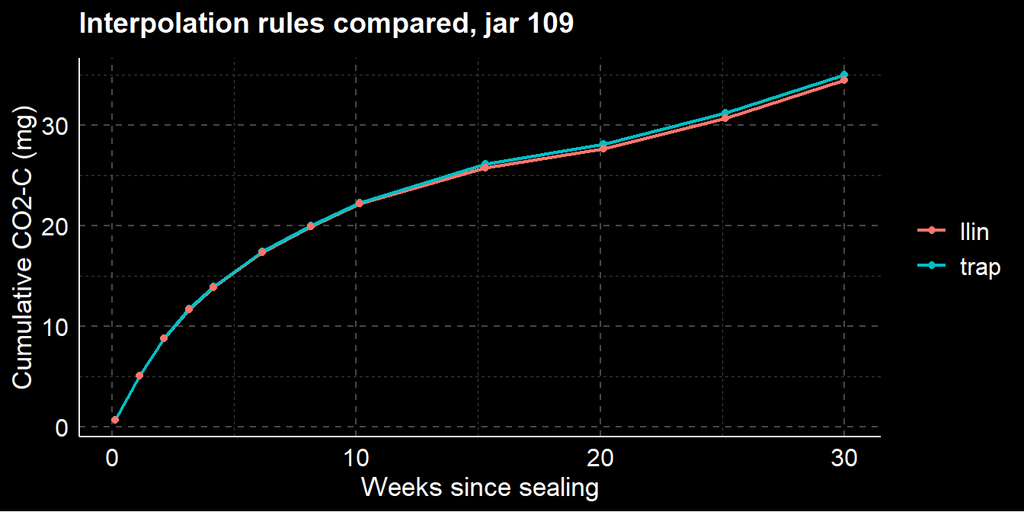

```r
# Where the two rules disagree, interval by interval, for one representative jar.
example_jar <- flux %>% filter(harvest == "T30", crop == "Wheat") %>% slice_head(n = 1) %>% pull(jar)

flux %>%
  filter(jar == example_jar) %>%
  arrange(t_day) %>%
  mutate(trap = cum_trap(t_day, flux_mg_jar_day),
         llin = cum_loglin(t_day, flux_mg_jar_day)) %>%
  select(t_day, trap, llin) %>%
  pivot_longer(c(trap, llin), names_to = "rule", values_to = "cum_mg") %>%
  ggplot(aes(t_day / 7, cum_mg, colour = rule)) +
  geom_line(linewidth = 0.8) + geom_point(size = 1.4) +
  labs(x = "Weeks since sealing", y = "Cumulative CO2-C (mg)", colour = NULL,
       title = paste("Interpolation rules compared, jar", example_jar))
```

# Caveats and suggested improvements

**Fitting cumulative curves.** Cumulative values are running sums of the same measurements, so successive points are not independent. The fits above are fine for point estimates of $k$ and $C_0$, but the standard errors from `summary(nls)` are optimistic. Fitting the flux form $dC/dt = C_0 k e^{-kt}$ to the raw fluxes gives honest uncertainty on the same two parameters; running both and comparing point estimates is a cheap check.

**Comparing crops statistically.** Rather than comparing per-jar $k$ with ANOVA — which discards the fitting uncertainty and the unequal series lengths — fit one nonlinear mixed model with crop as a fixed effect on both parameters and jar as a random effect: `nlme::nlme(cum_mg ~ SSasympOrig(t_day, Asym, lrc), fixed = Asym + lrc ~ crop, random = Asym + lrc ~ 1 | jar)`.

**Mixing-model assumptions.** The partitioning assumes (i) no isotopic fractionation during respiration, (ii) constant at% of the litter source through time, and (iii) that unlabeled jars give the right background. (ii) is the weak one: if the enriched labile fraction is consumed preferentially, the residual litter is less enriched than `T0_root_13C_at-pct`, so $f_{root}$ is biased low at later timepoints — which pushes cumulative litter-derived C in the opposite direction from a priming artifact. Measuring at% on the residual litter at each harvest would resolve it, and the harvested litterbags make that feasible.

**Moisture.** `jar_GWC` is per-jar; if it drifts between sampling dates, some flux variation is a moisture effect rather than a substrate effect. Plotting flux residuals against GWC is a quick screen.

**Root C estimate.** `T0_est-root-C_mg` is root mass × root C%, and root C% is a single composite per crop. That means its error is *systematic within a crop*, not random across jars: a composite that is 10% low scales every wheat jar’s denominator the same way and lifts the whole wheat curve, without adding any scatter that would make it visible as noise. This is the cheapest available explanation for a crop-specific mass-balance exceedance, and it is distinguishable from priming — priming should show up in the control-corrected series as well, whereas a bad composite affects only the root-C-normalized quantities. If any archived T0 root material remains, running C% on individual litterbags for the crop that overshoots would settle it directly.